# Week 11: Neural Networks — Foundations

Stat 577 — Statistical Learning Theory

Soumojit Das

Spring 2026

# Block 1: Recap + Python Setup

## Where We Left Off

In Week 9A we built the conceptual scaffolding for neural networks:

- **Step A:** Hidden layers learn new features from the raw input — like splines or polynomial features, but discovered from data rather than pre-specified
- **Step B:** The output layer classifies or predicts using those learned features — same as logistic regression or linear regression, but on top of the new representation
- **The full pipeline:** $\mathbf{x} \to$ hidden layers $\to$ learned features $\to$ output
- **Nonlinearity is essential:** without it, any number of layers collapses to a single linear transformation (the collapse theorem)
- **Training = minimize loss via SGD + backprop** — the loss surface is non-convex, but SGD navigates it effectively

**Today:** We formalize all of this — the math behind representation learning, backpropagation, and the practical machinery that makes training work.

## Python for Deep Learning: First Steps

**PyTorch’s killer feature:** automatic differentiation — compute gradients for free.

The core mechanism is **autograd**:

- `requires_grad=True` tells PyTorch to track every operation on a tensor
- `.backward()` traverses the computational graph **backward** to compute $\partial y / \partial x$
- The gradient is stored in `x.grad`

**Example:** For $f(x) = x^2 + 3x + 1$ at $x = 2$:

- `y = x**2 + 3*x + 1` builds the computational graph
- `y.backward()` computes $f'(x) = 2x + 3$, so $f'(2) = 7$
- `x.grad` returns `7.0`

This is the same chain rule we will formalize in Block 5 — PyTorch just does it automatically.

# Block 2: Representation Learning

## What Hidden Layers Actually Do

**ISLR’s insight:** Hidden units are learned basis functions — like splines or polynomial features, but learned from data rather than pre-specified.

This is Step A from 9A, now made precise: the hidden layer constructs a new feature space $\mathbf{z}$ in which the output layer (Step B) can succeed.

**ESL’s deeper insight:** Neural networks are a form of parametric projection pursuit regression (PPR).

PPR models:

$$f(\mathbf{x}) = \sum_{m=1}^{M} g_m(\boldsymbol{\omega}_m^T \mathbf{x})$$

where each $g_m$ is estimated **nonparametrically** (smoothing splines, etc.).

Neural networks fix $g_m = \sigma$ (a known parametric function):

$$f(\mathbf{x}) = \sum_{m=1}^{M} \beta_m \, \sigma(\boldsymbol{\alpha}_m^T \mathbf{x})$$

**Why this matters:** PPR can use only 5–10 terms (nonparametric $g_m$ is expensive to estimate). Neural networks, with the cheap parametric $\sigma$, can use 20–100+ terms — vastly more representational power.

## Deeper Networks

*For deeper networks, the per-unit ESL notation ($\alpha_m$, $\beta_k$) becomes cumbersome. We switch to matrix notation ($\mathbf{W}^{(\ell)}$, $\mathbf{b}^{(\ell)}$) for the general case.*

**Layer $\ell$ (hidden):** $\quad \mathbf{z}^{(\ell)} = \sigma\!\left(\mathbf{W}^{(\ell)}\mathbf{z}^{(\ell-1)} + \mathbf{b}^{(\ell)}\right), \quad \ell = 1, \ldots, L-1$

**Output layer:** $\quad f(\mathbf{x}) = g\!\left(\mathbf{W}^{(L)}\mathbf{z}^{(L-1)} + \mathbf{b}^{(L)}\right)$, where $g$ = identity (regression), sigmoid (binary), or softmax (multi-class)

**Composition:** $\quad f = f_L \circ f_{L-1} \circ \cdots \circ f_1$

Each layer learns progressively **more abstract features** — this is hierarchical feature learning:

- Layer 1: edges, local patterns
- Layer 2: combinations of edges — textures, shapes
- Layer 3: parts of objects
- Deeper layers: full concepts

This hierarchical composition is the fundamental reason deep networks outperform shallow ones.

## Counting Parameters

**MNIST example** (ISLR Ch 10): 784 inputs $\to$ 256 hidden $\to$ 128 hidden $\to$ 10 outputs.

| Layer | Weight matrix | Dimensions | Parameters |
| --- | --- | --- | --- |
| 1 | $\mathbf{W}^{(1)}$ | $256 \times (784 + 1)$ | $200{,}960$ |
| 2 | $\mathbf{W}^{(2)}$ | $128 \times (256 + 1)$ | $32{,}896$ |
| Output | $\mathbf{W}^{(3)}$ | $10 \times (128 + 1)$ | $1{,}290$ |
|  |  | **Total** | **$235{,}146$** |

Recall from 9A: 60,000 training images but 235,146 parameters — **4x** overparameterized. How this works is a central question for Block 6.

## Universal Approximation Theorem

**Universal Approximation (Cybenko 1989, Hornik 1991)**

For any continuous function $f: [0,1]^p \to \mathbb{R}$ and any $\epsilon > 0$, there exists a single hidden layer network with $M$ sigmoid units and weights $\boldsymbol{\alpha}_1, \ldots, \boldsymbol{\alpha}_M$, $\boldsymbol{\beta}$ such that

$$\left|f(\mathbf{x}) - \left[\beta_0 + \sum_{m=1}^{M} \beta_m \, \sigma(\alpha_{0m} + \boldsymbol{\alpha}_m^T\mathbf{x})\right]\right| < \epsilon \quad \text{for all } \mathbf{x} \in [0,1]^p$$

**What UAT Does NOT Say**

1. **How many** neurons $M$ you need — could be astronomically large
2. **That gradient descent will find** the right weights — only guarantees existence
3. **That this is the best architecture** — says nothing about depth vs width

ISLR: *“In theory a single hidden layer with a large number of units has the ability to approximate most functions. However, the learning task of discovering a good solution is made much easier with multiple layers each of modest size.”*

## Why Depth Beats Width

**Expressivity** of a ReLU network = number of **linear regions** it can represent.

- **Wide** (single layer, $M$ units): $O(M)$ linear regions
- **Deep** ($L$ layers, $M$ units each): up to $O(M^L)$ linear regions — exponential in depth! (Montufar et al. 2014)

Same number of neurons, vastly different expressive power.

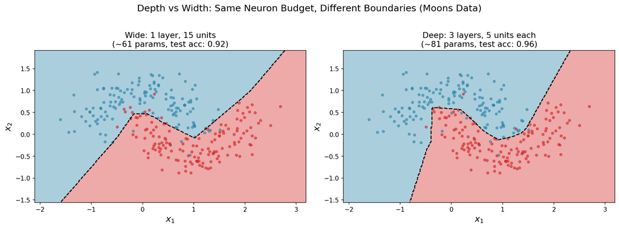

# Block 3: Activation Functions

## The Activation Function Zoo

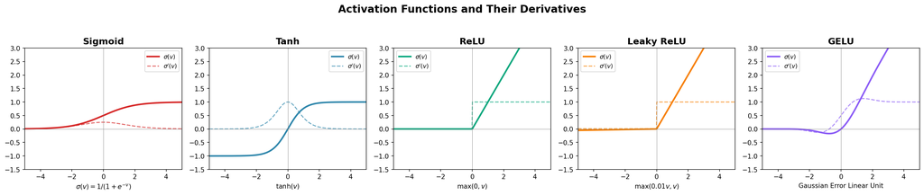

- **Sigmoid:** $\sigma(z) = \frac{1}{1+e^{-z}}$ — maps to $(0, 1)$. Historical default; saturates at extremes.
- **Tanh:** $\tanh(z) = 2\sigma(2z) - 1$ — maps to $(-1, 1)$. Zero-centered, but still saturates.
- **ReLU:** $\max(0, z)$ — simple, no saturation for $z > 0$. The modern default.
- **Leaky ReLU:** $\max(0.01z, z)$ — fixes “dying ReLU” with a small negative slope.
- **GELU:** $z \cdot \Phi(z)$ where $\Phi$ is the standard normal CDF — smooth, non-monotonic gate used in Transformers (GPT, BERT).

## Choosing an Activation Function

**Practical Advice**

- **ReLU is the default.** Start here. It is computationally trivial ($\max(0,z)$), avoids saturation for $z > 0$, and induces sparsity.
- **Sigmoid/Tanh:** Only for output layers (sigmoid for binary probability, tanh for bounded outputs) or legacy architectures. Never in hidden layers of deep networks.
- **Leaky ReLU:** If you observe dying neurons (many hidden units permanently outputting zero), switch to Leaky ReLU.
- **GELU:** Modern alternative used in Transformers. Marginal gains in some architectures, but adds computational cost.

**When in doubt, start with ReLU.**

# Block 4: Output Layers & Loss Functions

## The Output Layer Encodes Your Distributional Assumption

The **hidden layers** learn features. The **output layer** encodes your statistical model for $Y | \mathbf{X}$.

The choice of:

1. **Output activation function** $g_k(\cdot)$
2. **Loss function** $R(\boldsymbol{\theta})$

…together define an **implicit distributional assumption** about the response.

This is the bridge between neural networks and the statistical modeling framework we have built all semester.

## Regression: Identity Output + Squared Error Loss

**Output activation:** Identity (no nonlinearity at the output)

$$f(\mathbf{x}) = T = \beta_0 + \boldsymbol{\beta}^T \mathbf{z}$$

**Loss:**

$$R(\boldsymbol{\theta}) = \sum_{i=1}^{n} \bigl(y_i - f_{\boldsymbol{\theta}}(\mathbf{x}_i)\bigr)^2$$

**Statistical interpretation:** This assumes $Y | \mathbf{X} \sim N\!\left(f(\mathbf{x}),\, \sigma^2\right)$.

Minimizing MSE is **equivalent** to maximizing the Gaussian log-likelihood:

$$\ell(\boldsymbol{\theta}) = -\frac{n}{2}\log(2\pi\sigma^2) - \frac{1}{2\sigma^2}\sum_{i=1}^n (y_i - f_{\boldsymbol{\theta}}(\mathbf{x}_i))^2$$

The second term is just $-\frac{1}{2\sigma^2} R(\boldsymbol{\theta})$, so $\arg\min R = \arg\max \ell$.

## Classification: Sigmoid/Softmax + Cross-Entropy

**Binary classification** ($K = 2$):

- Output: $\hat{p}(\mathbf{x}) = \sigma(T) = \frac{1}{1 + e^{-T}}$
- Loss: $R(\boldsymbol{\theta}) = -\sum_{i=1}^n \bigl[y_i \log \hat{p}_i + (1 - y_i)\log(1 - \hat{p}_i)\bigr]$

**Multi-class classification** ($K > 2$):

- Output: softmax — $f_k(\mathbf{x}) = \dfrac{e^{T_k}}{\sum_{j=1}^K e^{T_j}}$, ensuring $\sum_k f_k = 1$
- Loss: $R(\boldsymbol{\theta}) = -\sum_{i=1}^{n} \sum_{k=1}^{K} y_{ik} \log f_k(\mathbf{x}_i)$

**Week 6 callback:** This is EXACTLY the multinomial logistic regression criterion — but applied to the **learned hidden features** $\mathbf{z}$ instead of the raw inputs $\mathbf{x}$.

## The Loss Function IS Maximum Likelihood

**The Unifying Principle**

Every standard neural network loss function is just negative log-likelihood under a distributional assumption:

| Loss | Distribution | Output activation |
| --- | --- | --- |
| MSE | Gaussian $Y \| \mathbf{X} \sim N(f(\mathbf{x}), \sigma^2)$ | Identity |
| Binary cross-entropy | Bernoulli $Y \| \mathbf{X} \sim \text{Bern}(\sigma(T))$ | Sigmoid |
| Categorical cross-entropy | Multinomial $Y \| \mathbf{X} \sim \text{Cat}(\text{softmax}(\mathbf{T}))$ | Softmax |

Neural networks do not abandon statistics — they embrace it at the output layer while learning features at the hidden layers.

# Block 5: Backpropagation

## The Central Problem: How to Compute Gradients

To train a neural network, we need:

$$\frac{\partial R}{\partial \theta_j} \quad \text{for ALL parameters } \theta_j$$

**Naive approach:** perturb each parameter, use finite differences:

$$\frac{\partial R}{\partial \theta_j} \approx \frac{R(\theta_j + \epsilon) - R(\theta_j)}{\epsilon}$$

Cost: $O(P)$ forward passes for $P$ parameters — with $P = 235{,}146$ (MNIST), this is impractical.

**Backpropagation:** Compute ALL gradients in a single backward pass — cost $\approx O(P)$, roughly the same as one forward pass.

Backpropagation is not a separate optimization algorithm — it IS the chain rule, applied systematically to the computational graph.

## Forward Pass: Setting Up a Concrete Example

Consider a small network: $p = 2$ inputs, $M = 2$ hidden units, 1 output.

**Forward pass** for a single observation $(\mathbf{x}_i, y_i)$:

**Step 1 — Pre-activations:**

$$v_1 = \alpha_{01} + \alpha_{11}x_1 + \alpha_{21}x_2, \qquad v_2 = \alpha_{02} + \alpha_{12}x_1 + \alpha_{22}x_2$$

**Step 2 — Hidden activations:**

$$Z_1 = \sigma(v_1), \qquad Z_2 = \sigma(v_2)$$

**Step 3 — Output:**

$$f = \beta_0 + \beta_1 Z_1 + \beta_2 Z_2$$

**Step 4 — Loss (for one observation):**

$$R_i = \tfrac{1}{2}(y_i - f)^2$$

## The Chain Rule Through the Computational Graph

The computational graph encodes the **dependency structure** of the computation:

$$\mathbf{x} \;\xrightarrow{\;\boldsymbol{\alpha}\;}\; \mathbf{v} \;\xrightarrow{\;\sigma\;}\; \mathbf{Z} \;\xrightarrow{\;\boldsymbol{\beta}\;}\; f \;\xrightarrow{\;(\cdot)^2\;}\; R$$

To find $\frac{\partial R}{\partial \alpha_{11}}$, the chain rule gives:

$$\frac{\partial R}{\partial \alpha_{11}} = \underbrace{\frac{\partial R}{\partial f}}_{\text{output error}} \cdot \underbrace{\frac{\partial f}{\partial Z_1}}_{\text{output weight}} \cdot \underbrace{\frac{\partial Z_1}{\partial v_1}}_{\sigma'(v_1)} \cdot \underbrace{\frac{\partial v_1}{\partial \alpha_{11}}}_{x_1}$$

Each factor corresponds to **one edge** in the computational graph.

Many of these factors are **shared** across different parameter gradients. Backpropagation exploits this sharing.

## Backward Pass: Output Layer Gradients

Starting from the loss $R_i = \frac{1}{2}(y_i - f)^2$:

**Output error signal** (gradient of loss w.r.t. prediction):

$$\delta_i \;=\; \frac{\partial R_i}{\partial f} \;=\; -(y_i - f)$$

**Gradients w.r.t. output-layer weights** (ESL eq 11.14, ISLR eq 10.29):

$$\frac{\partial R_i}{\partial \beta_m} = \delta_i \cdot Z_{mi}, \qquad \frac{\partial R_i}{\partial \beta_0} = \delta_i$$

These are simple: each gradient is the error signal times the corresponding hidden activation.

**For multi-output networks** ($K$ outputs): $\delta_{ki} = -(y_{ik} - f_k(\mathbf{x}_i))$ for regression (identity output). For classification with softmax + cross-entropy, the gradient w.r.t. the logit $T_k$ takes the same clean form: $\delta_{ki} = -(y_{ik} - p_k(\mathbf{x}_i))$, thanks to a special cancellation between softmax and cross-entropy.

## Backward Pass: Hidden Layer Gradients

Now propagate the error **backward** through the hidden layer.

**Hidden error signal** (ESL eq 11.15):

$$s_{mi} = \sigma'(v_{mi}) \sum_{k=1}^{K} \beta_{km}\, \delta_{ki}$$

**Gradients w.r.t. input-layer weights** (ESL eq 11.14, ISLR eq 10.30):

$$\frac{\partial R_i}{\partial \alpha_{jm}} = s_{mi} \cdot x_{ji}$$

**The key:** hidden-layer errors $s_{mi}$ are computed by back-propagating output errors $\delta_{ki}$ through the weights $\beta_{km}$ and the activation derivative $\sigma'(v_{mi})$.

This is where the name “back-propagation” comes from — errors flow **backward** through the network, from output to input.

## The General Backpropagation Algorithm

**Backpropagation (two-pass algorithm)**

**Forward pass:** Compute and store all activations, layer by layer:

$$\mathbf{z}^{(0)} = \mathbf{x}, \qquad \mathbf{z}^{(\ell)} = \sigma\!\left(\mathbf{W}^{(\ell)}\mathbf{z}^{(\ell-1)} + \mathbf{b}^{(\ell)}\right), \quad \ell = 1, \ldots, L-1$$
$$\mathbf{f} = g\!\left(\mathbf{W}^{(L)}\mathbf{z}^{(L-1)} + \mathbf{b}^{(L)}\right)$$

where $g$ = identity (regression), sigmoid (binary), or softmax (multi-class).

**Backward pass:** Compute error signals, from output back to input:

$$\boldsymbol{\delta}^{(L)} = \nabla_{\mathbf{f}} R, \qquad \boldsymbol{\delta}^{(\ell)} = \sigma'\!\left(\mathbf{v}^{(\ell)}\right) \odot \left[(\mathbf{W}^{(\ell+1)})^T \boldsymbol{\delta}^{(\ell+1)}\right], \quad \ell = L\!-\!1, \ldots, 1$$

**Gradients:** $\quad \dfrac{\partial R}{\partial \mathbf{W}^{(\ell)}} = \boldsymbol{\delta}^{(\ell)} \left(\mathbf{z}^{(\ell-1)}\right)^T, \qquad \dfrac{\partial R}{\partial \mathbf{b}^{(\ell)}} = \boldsymbol{\delta}^{(\ell)}$

**Update:** $\quad \boldsymbol{\theta} \leftarrow \boldsymbol{\theta} - \eta \nabla R(\boldsymbol{\theta})$

**Efficiency:** Each gradient is computed exactly once. Total cost $\approx$ 2x the cost of a single forward pass.

**Backprop Summary**

**1.** Backpropagation is the chain rule applied to a computational graph.

**2.** The forward pass stores activations; the backward pass computes gradients from output to input.

**3.** Total cost $\approx$ 2x one forward pass, regardless of the number of parameters.

**4.** Output gradients: error $\times$ activation. Hidden gradients: back-propagated through weights.

**[Interactive Backprop Walkthrough](https://soumojitdas.github.io/stat577/lecture-slides/nn-backprop-walkthrough.html)** — step through a 2→2→1 network with concrete numbers, forward and backward

# Block 6: Optimization & Training

## Gradient Descent

Given the loss $R(\boldsymbol{\theta}) = \sum_{i=1}^n R_i(\boldsymbol{\theta})$, the full-batch gradient descent update is:

$$\boldsymbol{\theta}^{(t+1)} = \boldsymbol{\theta}^{(t)} - \eta \,\nabla R\bigl(\boldsymbol{\theta}^{(t)}\bigr)$$

**$\eta$ = learning rate** — the single most important hyperparameter in deep learning.

- Too large: diverges (overshoots minima)
- Too small: converges too slowly, gets trapped in sharp local minima

**Problem:** Computing $\nabla R$ requires summing over **all** $n$ observations — for ImageNet ($n = 1.2$ million), one gradient step = one full pass through the data.

## Stochastic Gradient Descent (SGD)

**Idea:** Use a random **minibatch** $\mathcal{B} \subset \{1, \ldots, n\}$ to approximate the full gradient:

$$\boldsymbol{\theta}^{(t+1)} = \boldsymbol{\theta}^{(t)} - \eta \,\frac{1}{|\mathcal{B}|} \sum_{i \in \mathcal{B}} \nabla R_i\bigl(\boldsymbol{\theta}^{(t)}\bigr)$$

**Properties:**

- **Unbiased:** $\mathbb{E}_{\mathcal{B}}\!\left[\frac{1}{|\mathcal{B}|}\sum_{i \in \mathcal{B}} \nabla R_i\right] = \nabla R$ (in expectation, equals the full gradient)
- Typical batch sizes: 32, 64, 128, 256
- **Epoch** = one complete pass through the training set ($n / |\mathcal{B}|$ updates)

## GD vs SGD: Same Start, Different Paths

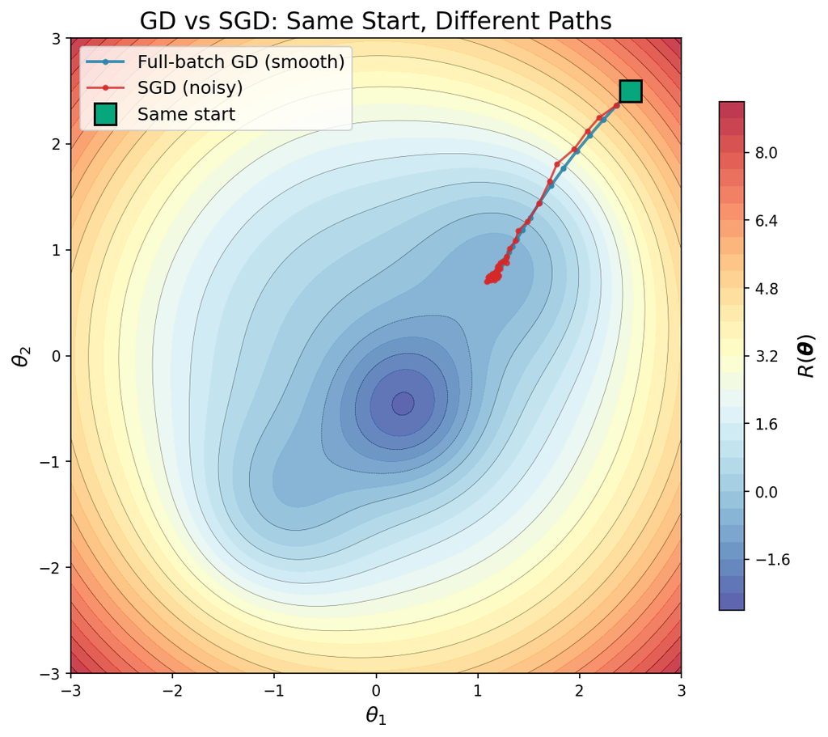

Full-batch GD takes clean, deterministic steps toward the nearest minimum. SGD adds noise from minibatch sampling — the path is jittery but still converges. The noise is not a bug; it is a feature.

## Why SGD Noise Helps

The surprising benefit of stochastic noise:

- **Sharp minima generalize poorly; flat minima generalize well.** Sharp minima are sensitive to small perturbations in the data — high test error. Flat minima are robust.
- **SGD noise bounces the parameters out of sharp minima.** The random fluctuations from minibatch sampling make it hard to stay in narrow, sharp basins.
- **Noise magnitude scales with $\eta$ and inversely with $|\mathcal{B}|$.** Larger learning rate or smaller batch = more noise = stronger preference for flat minima.
- This is **implicit regularization** — SGD naturally prefers flat minima without an explicit penalty term.

ISLR: *“SGD naturally enforces its own form of approximately quadratic regularization.”*

Empirically: solutions found by SGD generalize **better** than those found by full-batch GD, even when both reach the same training loss.

## The Non-Convex Loss Landscape

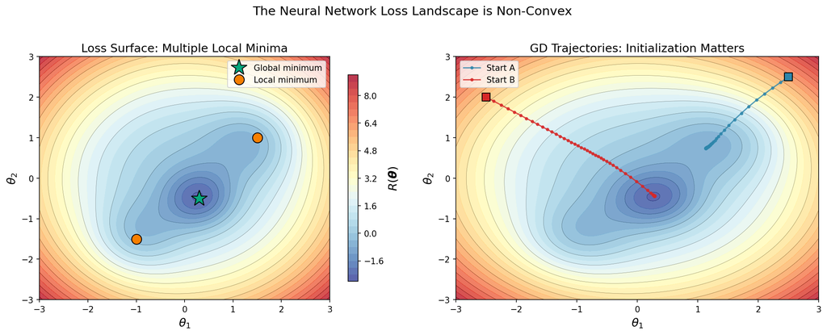

$R(\boldsymbol{\theta})$ is **highly non-convex** — many local minima, saddle points, and plateaus.

## Non-Convexity: Not As Bad As It Looks

The modern understanding of why neural network optimization works despite non-convexity:

- **Saddle points dominate in high dimensions.** In a $P$-dimensional parameter space, a critical point requires all $P$ eigenvalues of the Hessian to be positive for a local minimum. Saddle points (mixed signs) are exponentially more common.
- **Local minima cluster near the global minimum.** Choromanska et al. (2015) showed that loss surfaces of large networks resemble spin glass models — exponentially many local minima, but they concentrate near the same loss value.
- **SGD noise helps escape saddle points.** At a saddle point the gradient is zero, but minibatch noise pushes parameters off the saddle along directions of negative curvature.
- **The practical implication:** Finding ANY local minimum is usually good enough. The obsession with the global minimum is a low-dimensional intuition that does not transfer to overparameterized networks.

## Training Dynamics: Watching a Network Learn

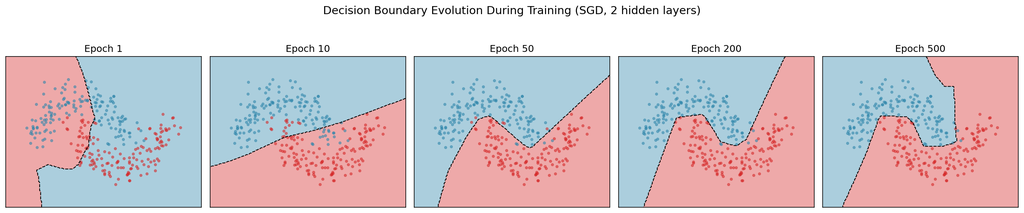

## The Vanishing Gradient Problem

Recall the sigmoid derivative:

$$\sigma'(v) = \sigma(v)\bigl(1 - \sigma(v)\bigr)$$

- **Maximum** at $v = 0$: $\sigma'(0) = 0.25$
- As $|v| \to \infty$: $\sigma'(v) \to 0$

In backpropagation, each layer **multiplies** by $\sigma'(v)$:

$$\boldsymbol{\delta}^{(\ell)} = \underbrace{\sigma'(\mathbf{v}^{(\ell)})}_{\leq 0.25} \odot \left[(\mathbf{W}^{(\ell+1)})^T \boldsymbol{\delta}^{(\ell+1)}\right]$$

For a network with $L$ layers, the gradient reaching layer 1 is multiplied by $\sigma'$ at each of $L - 1$ hidden layers:

$$\left|\frac{\partial R}{\partial \mathbf{W}^{(1)}}\right| \sim (0.25)^{L-1} \cdot \left|\frac{\partial R}{\partial \mathbf{W}^{(L)}}\right|$$

For $L = 10$: $(0.25)^9 \approx 3.8 \times 10^{-6}$ — the gradient has effectively vanished.

## Vanishing Gradients: The Evidence

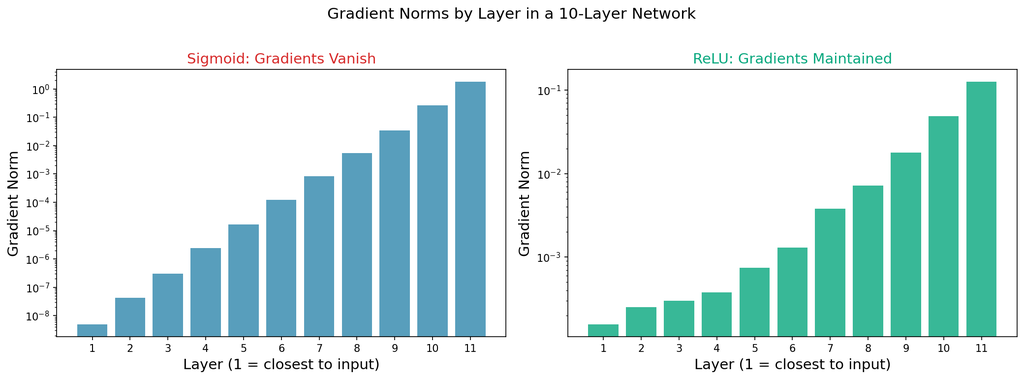

**Sigmoid** (left): gradient norms decay exponentially from the output layer toward the input — early layers stop learning.

## Weight Initialization

**Starting at exact zero:** Every hidden unit computes the same function — perfect symmetry. All gradients are identical. Nothing moves.

**Random near zero** (ESL): typical starting values $\sim U[-0.7, 0.7]$ with standardized inputs.

ESL: *“Starting with large weights typically leads to poor solutions.”*

ESL: *“With small weights, the network starts out approximately linear, and becomes nonlinear as the weights increase.”*

But HOW small? Random draws from $N(0, 0.01)$ work for shallow networks, but for deep networks the variance compounds across layers — we need a principled approach.

## Xavier and He Initialization

**The key idea:** Choose initial weights so the variance of activations is preserved across layers.

For one layer: $z = \sum_{i=1}^{n_{\text{in}}} w_i x_i$. If $w_i$ and $x_i$ are independent with $\mathbb{E}[w] = 0$ and $\mathbb{E}[x] = 0$ (this is why we standardize inputs):

$$\text{Var}(z) = n_{\text{in}} \cdot \text{Var}(w) \cdot \text{Var}(x)$$

Setting $\text{Var}(z) = \text{Var}(x)$ (preserve activation variance across layers):

$$\text{Var}(w) = \frac{1}{n_{\text{in}}}$$

| Method | Variance | Best for |
| --- | --- | --- |
| **Xavier/Glorot** (2010) | $\text{Var}(w) = \dfrac{2}{n_{\text{in}} + n_{\text{out}}}$ | Sigmoid, Tanh |
| **He/Kaiming** (2015) | $\text{Var}(w) = \dfrac{2}{n_{\text{in}}}$ | ReLU |

The factor of 2 in He initialization accounts for ReLU zeroing out approximately half the activations.

**Principle:** Choose weights so variance of activations AND gradients is approximately constant across layers — prevents both vanishing and exploding.

## Weight Decay

$$R_{\text{reg}}(\boldsymbol{\theta}) = R(\boldsymbol{\theta}) + \lambda \sum_j \theta_j^2$$

- ESL: *“analogous to ridge regression”*
- The gradient of the penalty is $2\lambda\theta_j$; in practice the factor of 2 is often absorbed into $\lambda$
- Controls model complexity by shrinking weights toward zero

The penalty applies to **all** weights in the network — input-to-hidden, hidden-to-hidden, and hidden-to-output. Bias terms are typically excluded (just as in ridge regression, we do not penalize the intercept).

Typical values: $\lambda \sim 10^{-4}$ to $10^{-2}$, tuned via validation loss.

## Early Stopping

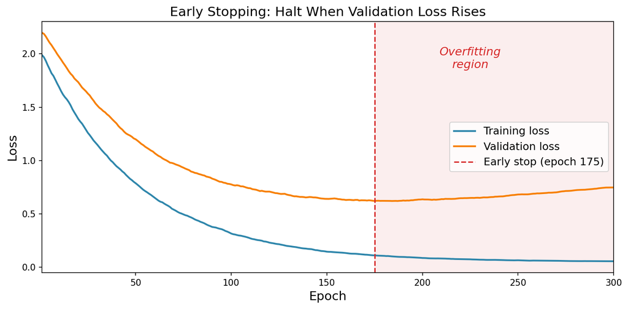

- **Stop training when validation loss begins to increase** — the simplest and most effective regularizer.
- ESL: *“Starting from weights near zero (approximately linear), early stopping shrinks the final model toward a linear model.”*
- Controls complexity through the **number of gradient steps**, not an explicit penalty. More steps = more nonlinearity = more capacity.

## Multiple Random Starts

Since the loss surface is non-convex, different initializations may lead to different solutions.

**Strategy:** Train $K$ networks with different random seeds, then **average their predictions**:

$$\hat{f}_{\text{avg}}(\mathbf{x}) = \frac{1}{K}\sum_{k=1}^K \hat{f}_k(\mathbf{x})$$

**Average Predictions, Not Weights**

ESL: *“Averaging predictions from different starting points is better than averaging the parameter values, because the nonlinearity of the model makes the averaged-weight solution a poor predictor.”*

$$\frac{1}{K}\sum_k f(\mathbf{x}; \boldsymbol{\theta}_k) \;\neq\; f\!\left(\mathbf{x}; \frac{1}{K}\sum_k \boldsymbol{\theta}_k\right)$$

This is the same principle behind bagging and random forests (Weeks 7–8) — averaging reduces variance.

## Putting It All Together: A Practitioner’s Checklist

**Neural Network Training Checklist**

**1. Preprocessing:** Standardize inputs to mean 0, standard deviation 1. One-hot encode categorical variables.

**2. Architecture:** Start with ReLU activations. Err on the side of too many hidden units + regularization (easier to regularize an overparameterized model than to increase capacity).

**3. Initialization:** He (Kaiming) for ReLU; Xavier/Glorot for sigmoid/tanh.

**4. Training:** SGD or Adam optimizer, batch size 32–256. Monitor training AND validation loss every epoch.

**5. Regularization:** Early stopping (always). Weight decay ($\lambda \sim 10^{-4}$ to $10^{-2}$). Try averaging over multiple random starts.

**6. Diagnostics:** Plot loss curves — look for training/validation divergence. Check gradient norms per layer — watch for vanishing/exploding.

# Summary & Looking Ahead

## Key Takeaways

**Seven Things to Remember**

**1.** ReLU is the default activation — sigmoid/tanh cause vanishing gradients in deep networks.

**2.** Every standard loss function is negative log-likelihood under a distributional assumption (MSE $\leftrightarrow$ Gaussian, cross-entropy $\leftrightarrow$ Bernoulli/Multinomial).

**3.** Backpropagation = the chain rule on a computational graph. Cost $\approx$ 2x one forward pass for ALL gradients.

**4.** Vanishing gradients: sigmoid multiplies by $\leq 0.25$ per layer; in a 10-layer network, early layers see gradients shrunk by $10^6$.

**5.** Xavier/He initialization maintains activation variance across layers — prevents both vanishing and exploding.

**6.** SGD noise is implicit regularization — it prefers flat minima that generalize better.

**7.** The regularization toolkit: weight decay (ridge on weights), early stopping (shrinks toward linear), multiple random starts (variance reduction).

## Connection Map

**Weeks 2–3 (Linear Models + Regularization)**

A neural network with no hidden layers IS a linear model. Weight decay IS ridge regression. Early stopping implicitly regularizes by shrinking the model toward its approximately linear initialization.

**Weeks 7–8 (Trees + Ensembles)**

Averaging predictions from multiple random starts parallels bagging — both reduce variance by combining diverse learners trained on different sources of randomness.

## Looking Ahead: Deep Learning

**What Comes Next**

**1. Batch Normalization** — normalize activations within each layer, stabilize training dynamics

**2. Dropout** — randomly zero out neurons during training, prevent co-adaptation (neural network’s version of random feature subsets)

**3. Adam Optimizer** — adaptive learning rates per parameter, faster convergence than vanilla SGD

**4. Convolutional Neural Networks (CNNs)** — weight sharing + local connectivity for image data, the architecture that launched the deep learning revolution

The foundations from this week (backprop, loss functions, activations) do not change — modern deep learning adds engineering innovations that make these foundations scale.